# Story_of_How_the_World_Food_Shortage_Problem_can_be_Solved slides

### Although this dataset contains 94 food items, the world as a whole produces and consumes some certain food crops in excess, so I will be focusing on those food items to see how their production and supply affects food shortage.

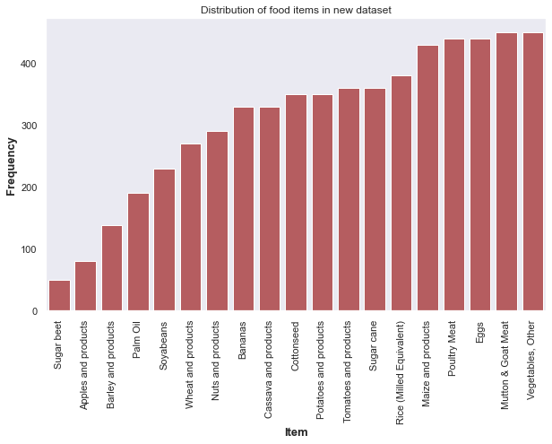

### From the above plot we can see that even among the most produced foods, some are massively produced than others. The top 8 produced foods include vegetables, mutton & goat meat, Eggs, Poultry meat, Maize and products, Rice, Sugarcane and Tomatoes and products.

|  | Country | Item | Year | Value |
| --- | --- | --- | --- | --- |
| count | 5918 | 5918 | 5918.000000 | 5918.000000 |
| unique | 45 | 19 | NaN | NaN |
| top | Madagascar | Vegetables, Other | NaN | NaN |
| freq | 170 | 450 | NaN | NaN |
| mean | NaN | NaN | 2008.498648 | 721.607131 |
| std | NaN | NaN | 2.872053 | 2573.699346 |
| min | NaN | NaN | 2004.000000 | 0.000000 |
| 25% | NaN | NaN | 2006.000000 | 8.000000 |
| 50% | NaN | NaN | 2008.000000 | 48.000000 |
| 75% | NaN | NaN | 2011.000000 | 371.000000 |
| max | NaN | NaN | 2013.000000 | 54000.000000 |

### From the table above we can see that the most mentioned country is madagascar being mentioned 170 times, the most produced item is vegetable/other validating the distribution of food items plot above, and most food item's value fall in the 48 range. With a food item displaying an outlier value of 54000 and 0 respectively.

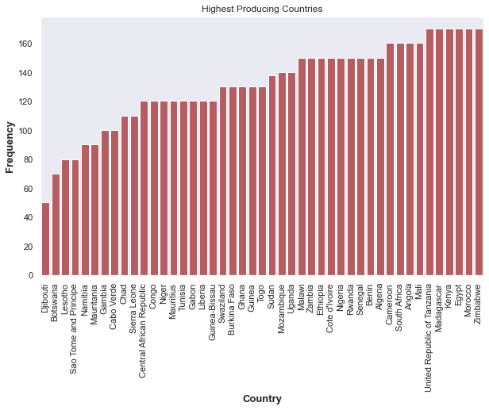

### From the plot above we can see food production is heavily skewed in favor of certain countries namely: Tanzania, madagascar, Kenya, Egypt, Morocco, Zimbabwe. While some other countries are heavily lacking in food production namely: Djibouti, Botswana, Lesotho, sao tome and principe, namibia and mauritania.

|  | Country | Item | Year | Value |
| --- | --- | --- | --- | --- |
| 15448 | Nigeria | Cassava and products | 2012 | 54000 |

### We can see above that Nigeria produced a very large amount(outlier) of cassava in the year 2012.

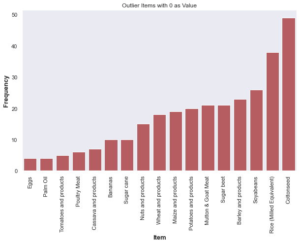

### we can see from the plot above that there were alot of years were cottonseed and rice were not produced at all, this is bad because rice especially is a most sought after food by majority of the world population.

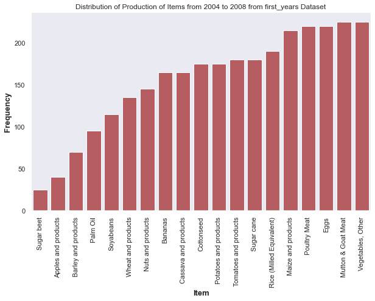

### From the plot above the top 8 produced foods stays relatively the same from 2004 to 2008.

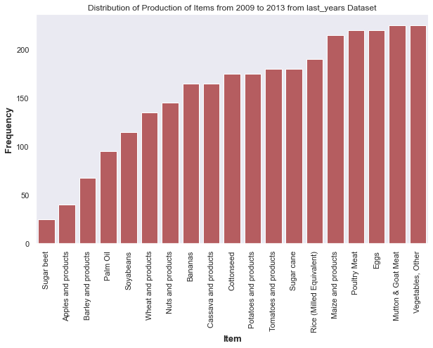

### From the plot above we can see that the top 8 most produced foods stay relatively the same from 2009 to 2013 further confirming our bias that some foods are disproportionately produced than others.

```
Country
Egypt                          369913
South Africa                   329657
Nigeria                        212769
Kenya                          100491
United Republic of Tanzania     96705
Name: Value, dtype: int64
```

### We can see that Egypt is the highest producing country of the most produced foods closely followed by SouthAfrica, Nigeria, Kenya and Tanzania. We can also that food production is not region specific as these 5 countries are in different parts of Africa.

```
Country
Gambia                   844
Cabo Verde               603
Botswana                 602
Djibouti                 345
Sao Tome and Principe    101
Name: Value, dtype: int64
```

### We can see that Sao Tome and Principe produces the lowest amount of the most produced foods, they are closely followed by Djibouti, Botswana, Cabo verde and Gambia. This is not a good sign because the gap between most and least producing countries is too large. If food shortage is to be solved then this discrepancy must be handled.

```
Country
Egypt        34580
Tunisia      33055
Morocco      32967
Algeria      31118
Mauritius    30543
Name: Value, dtype: int64
```

```
Country
Central African Republic    20719
Madagascar                  20608
Chad                        20511
Ethiopia                    20292
Zambia                      18701
Name: Value, dtype: int64
```

### We can also see another discrepancy here as the lowest producing countries does not correlate with the lowest supplying/consuming countries.

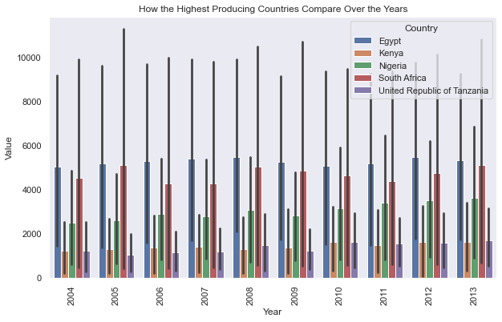

### From the above plot we can see that over the years Egypt, Nigeria and South Africa have generally been consistent in food production.

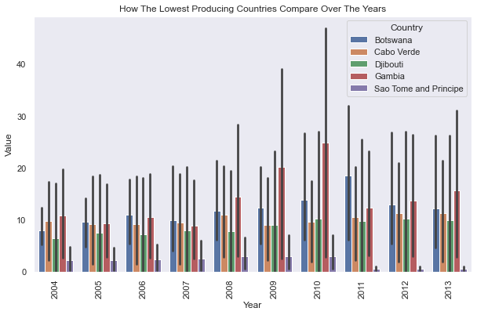

### From the plot above we can see that sao Tome and principe and Djibouti have consistently been producing the least amount of food.

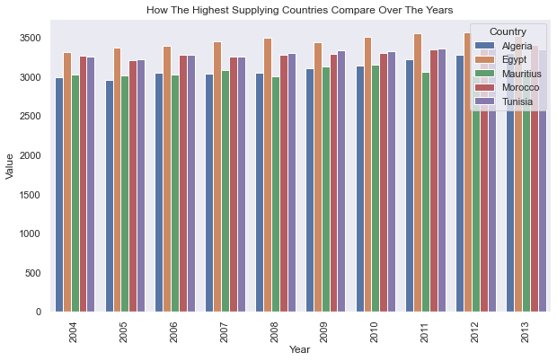

### From the plot above Egypt, morroco and Tunisia have consistently being supplying food over the years.

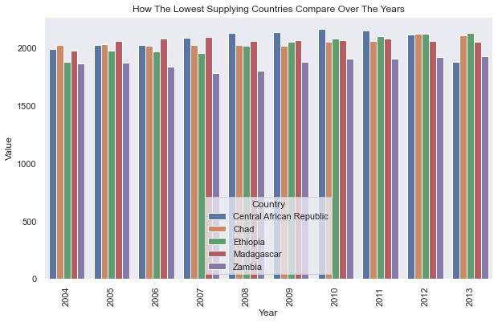

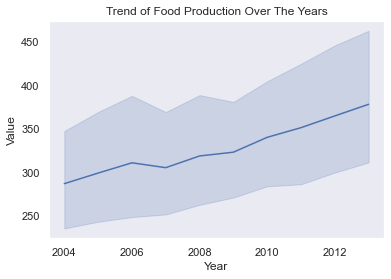

### Food production over the course of 9 years shows an upward trend.

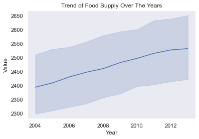

### Food supply and production show an upward trend over the course of 9 years indicating that food production is increasing while supply and consumption is keeping pace with it. It appears that to solve the food shortage problem some countries eg, Ethiopia, Djibouti and Sao Tome and Principe would need to improve their farming practices. Struggling countries can also increase their vegetable farming as it is a major source of food while being relatively easy to grow. It also seems like some foods grow better in some particular countries eg cassava in Nigeria, so it would be wise for countries to find out which food crops grow better in their weather and environ in order to focus on those crops. Also, the upward trend of both food production and supply is good telling us that the current farming sectors and practices can keep up with an increasing demand for food.